# How ‘class_weight’ works in tree-based algorithms

wy

2023-03-24

`class_weight` is a parameter that can be used in many models. It is specified as a dict mapping class labels to weights ({class_label: weight}), such that each sample of the named class is given that weight. It is a weighting method for training imbalanced samples.

One can find in the official documentation that: Class weights will be used differently depending on the algorithm,

- For **linear models** (such as linear SVM or logistic regression), the class weights will **alter the loss function** by weighting the loss of each sample by its class weight.

so take logistic regression for example:

$$CE = - y {\log\left( \hat{y} \right)} -
(1 - y) log\left( 1 - \hat{y} \right)$$
$$Weighted~CE = - \omega_{1} * y {\log\left(
\hat{y} \right)} - \omega_{0} * (1 - y) log\left( 1 - \hat{y}
\right)$$

- For **tree-based algorithms**, the class weights will be used for **reweighting the splitting criterion**.

But what does ‘reweighting the splitting criterion’ mean?

# example of Decision Tree Classifier

Here we take Binary Decision Tree (two classes: 0,1) for example.

$N_k$: number of samples belonging to class k.

the Gini criterion is defined as:

$$p_{k} = \frac{N_{k}}{\sum\limits_{k =
0}^{1}N_{k}}$$
$$Gini =
{\sum\limits_{k = 0}^{1}{p_{k}\left( {1 - p_{k}} \right)}} = 1 -
{\sum\limits_{k = 0}^{1}\left. \left( p \right._{k}
\right)^{2}}$$
if we give weights class_weight={$0:w_0,1:w1$}, then the Gini is calculated as:

$$p_{k}^{'} =
\frac{\omega_{k} N_{k}}{\sum\limits_{k =
0}^{1}{\omega_{k} N_{k}}}$$
$$Gini =
{\sum\limits_{k = 0}^{1}{p_{k}^{'} \left( {1 - p_{k}^{'}}
\right)}} = 1 - {\sum\limits_{k = 0}^{1}\left( p_{k}^{'}
\right)^{2}}$$

We can simulate a dataset to see if the formula is true or not,

Firstly we generate data like this

X=[[-1.73419291, 0.18198846],[ 0.37669975, -0.60601694],[-2.3067743, -2.37797482],[-0.92409942,-0.22962111],[ 0.19989479, -0.18271417]]

y=[0, 0, 1, 0, 1]

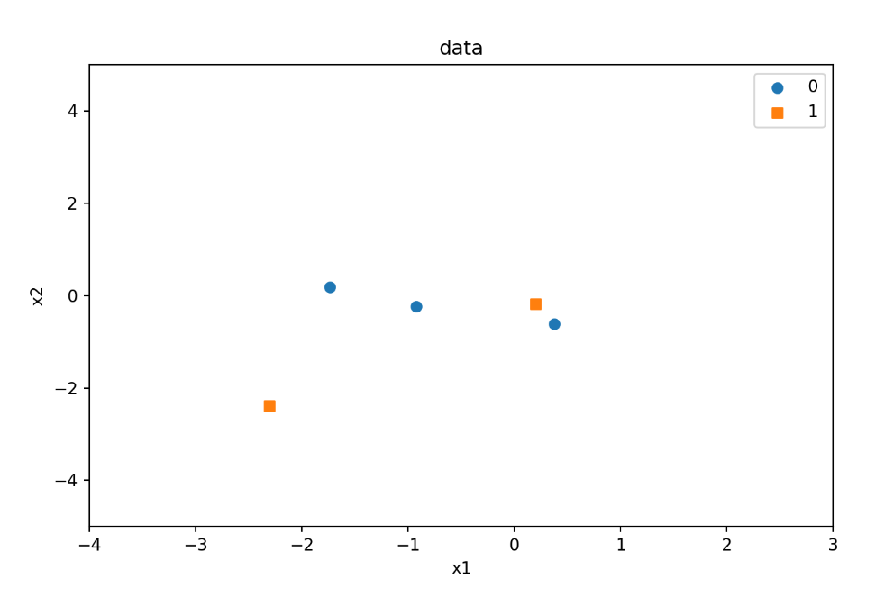

Then we train two DTC models, one without any weighting and the other with ‘class_weight={0:1,1:5}’

the tree models are output, and we can calculate the change of Gini of the whole data

- without class weight

$$p_0=\frac{3}{3+2}, ~
p_1=\frac{2}{3+2}\\Gini=1-p_0^2-p_1^2=0.48$$

- with class_weight={0:1,1:5}

$$p_0'=\frac{3*1}{3*1+2*5},~
p_1'=\frac{2*5}{3*1+2*5}\\Gini'=1-p_0'^2-p_1'^2=0.355$$

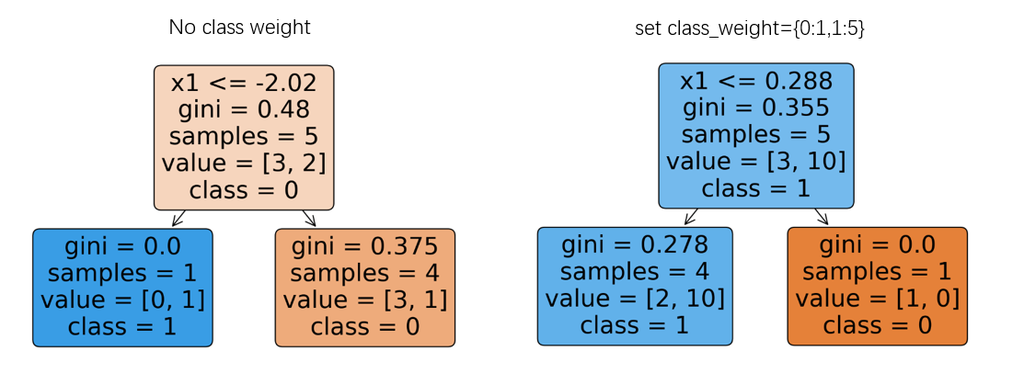

It can be seen from the figure below that weighting class 1 makes the model believe that **class 1 brings greater impurity**, so the way the decision tree is divided changed.

In this way, by weighting minority class (class which has a smaller sample size), we can let **the misclassification of minority class samples make a greater contribution to the loss**, preventing the model from dividing all samples into the majority class due to class-imbalance.

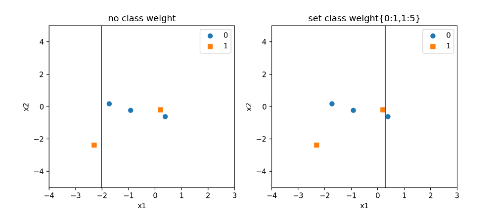

# source code of ‘class_weight’ in tree-based algorithms

https://github.com/scikit-learn/scikit-learn/blob/d4d5f8c7e02cfaced76757fbf38e21c5b28b67b0/sklearn/tree/_criterion.pyx

So the mechanism of how this parameter works is clear enough – if the given weight of class A is `w`, then **each sample of class A is regarded as important as `w` times the original one**.

```python
for p in range(start, end):
    i = samples[p]

    # w is originally set to be 1.0, meaning that if no sample weights
    # are given, the default weight of each sample is 1.0
    if sample_weight != NULL:
        w = sample_weight[i]

    # Count weighted class frequency for each target
    for k in range(self.n_outputs):
        c = <SIZE_t> self.y[i, k]
        sum_total[k * self.sum_stride + c] += w

    self.weighted_n_node_samples += w
```

# References

https://scikit-learn.org/stable/glossary.html#term-class_weight

https://datascience.stackexchange.com/questions/56250/how-does-class-weight-work-in-decision-tree

https://github.com/scikit-learn/scikit-learn/blob/d4d5f8c7e02cfaced76757fbf38e21c5b28b67b0/sklearn/tree/_criterion.pyx

# Appendix

code of example above:

```python
import numpy as np
import pandas as pd
import matplotlib.pyplot as plt
import sklearn.tree as Tree
from sklearn import datasets

# generate data
# X: two dimensions
# y: one dimension, class 0/1
X,y = datasets.make_classification(n_samples = 5,
                                   n_features = 2,
                                   n_informative=2,
                                   n_classes = 2,
                                   n_redundant=0,
                                   n_repeated=0,
                                   shuffle=False,
                                   #n_clusters_per_class=1,
                                   class_sep=0.3,
                                   weights = [0.6,0.4],
                                   random_state=1)

# plot the data
colors = ['#1F77B4', '#FF7F0E']
markers = ['o', 's']
for l, c, m in zip(np.unique(y), colors, markers):
    plt.scatter(
            X[y==l, 0],
            X[y==l, 1],
            c=c, label=l, marker=m
        )
plt.xlim(-4, 3)
plt.ylim(-5, 5)
plt.xlabel('x1')
plt.ylabel('x2')
plt.title('data')
plt.legend(loc='upper right')
plt.show()


# train model
modelDTC0=Tree.DecisionTreeClassifier(max_depth=1,random_state=123)
modelDTC0.fit(X,y)

# train model with 'class_weight={0:1,1:5}'
modelDTC1=Tree.DecisionTreeClassifier(max_depth=1,random_state=123,class_weight={0:1,1:5})
modelDTC1.fit(X,y)

# plot the results
feature_names=['x1','x2']
Tree.plot_tree(modelDTC0,feature_names=feature_names,class_names=['0','1'],filled=True,rounded=True)
Tree.plot_tree(modelDTC1,feature_names=feature_names,class_names=['0','1'],filled=True,rounded=True)

# plot the results
fig,axes=plt.subplots(nrows=1,ncols=2,figsize=(10,4))
for l, c, m in zip(np.unique(y), colors, markers):
    axes[0].scatter(
            X[y==l, 0],
            X[y==l, 1],
            c=c, label=l, marker=m
        )
axes[0].set_xlim(-4, 3)
axes[0].set_ylim(-5, 5)
axes[0].set_xlabel('x1')
axes[0].set_ylabel('x2')
axes[0].axvline(x=-2.02,c='r')
axes[0].set_title('no class weight')
axes[0].legend(loc='upper right')


for l, c, m in zip(np.unique(y), colors, markers):
    axes[1].scatter(
            X[y==l, 0],
            X[y==l, 1],
            c=c, label=l, marker=m
        )
axes[1].set_xlim(-4, 3)
axes[1].set_ylim(-5, 5)
axes[1].set_xlabel('x1')
axes[1].set_ylabel('x2')
axes[1].axvline(x=0.288,c='r')
axes[1].set_title('set class weight{0:1,1:5}')
axes[1].legend(loc='upper right')
plt.show()
```